# Homework 1

Yigit Memceroktay

2024-04-06

# Introduction

Author: Yiğit Memceroktay

Number:2020402006

Course: IE360

#### The data-sets that I chose for the analysis are: CPI of Turkey (consumer price index), Unemployment rate and total house sales in Turkey. The data-sets contain data for the dates between 1/1/2015-1/12/2021.

Importing packages

```r
require(data.table)
require(lubridate)
require(forecast)
require(repr)
require(openxlsx)
require(ggplot2)
require(data.table)
require(skimr)
require(GGally)
require(ggcorrplot)
require(forecast)
require(tidyverse)
require(htmltools)
require(readxl)
require(corrplot)

library(reshape2)
library(corrplot)
library(readxl)
library(tidyverse)
library(data.table)
library(lubridate)
library(forecast)
library(skimr)
library(repr)
```

Imported the excel file that contains 3 data-sets for time-series analysis. The data-sets that I chose are: CPI (consumer price index), unemployment rate, and total amount of houses sold. The table below shows the correlation between the data-sets. As you can see, no two pair has correlation more than 0.5 therefore the data-sets are suitable for this project.

```r
options(repr.plot.width=12.7, repr.plot.height=8)

data_path='C:\\Users\\Yalikent\\Downloads\\forecast.xlsx'
forecast_data = read_excel(data_path, sheet="EVDS")
forecast_data_table =  as.data.table(forecast_data)
cor_matrix = cor(forecast_data_table)
melted_cor_matrix <- melt(cor_matrix)
```

Correlation Table

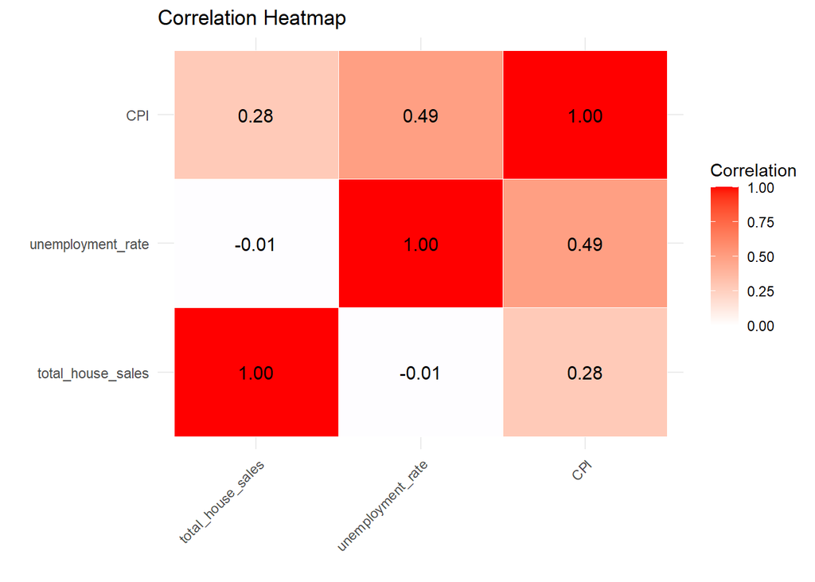

```r
# Use ggplot to create the heatmap
ggplot(melted_cor_matrix, aes(Var1, Var2, fill = value)) +
  geom_tile(color = "white") +
  scale_fill_gradient2(low = "blue", mid = "white", high = "red", midpoint = 0) +
  theme_minimal() +
  theme(axis.text.x = element_text(angle = 45, hjust = 1)) +
  labs(x = '', y = '', title = 'Correlation Heatmap', fill = 'Correlation') +
  geom_text(aes(label = sprintf("%.2f", value)), color = "black", size = 4)
```

Importing the excel file that contains both the forecast variables (CPI, etc.) and predictor variables (number of searches on google, consumer confidence index etc.)

```r
data_path='C:\\Users\\Yalikent\\Downloads\\Book2.xlsx'
all_data <- read_excel(data_path)
all_data_table=data.table(all_data)
```

# Model 1 (Total House Sales in Turkey)

In the initial model, my objective is to examine the data-set representing the total number of house sales in Turkey. The subsequent graph illustrates the overall house sales spanning from 2015 to 2021 in Turkey.

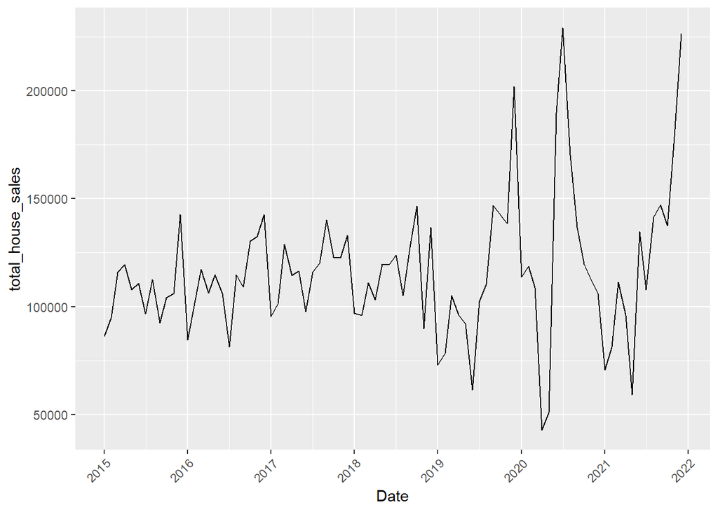

```r
all_data_table[, Date := as.Date(Date, format = "%Y-%m-%d")]
ggplot(all_data_table ,aes(x=Date,y=total_house_sales, group=1)) + geom_line() + scale_x_date(date_breaks = "1 year", date_labels = "%Y") +
  theme(axis.text.x = element_text(angle = 45, hjust = 1))
```

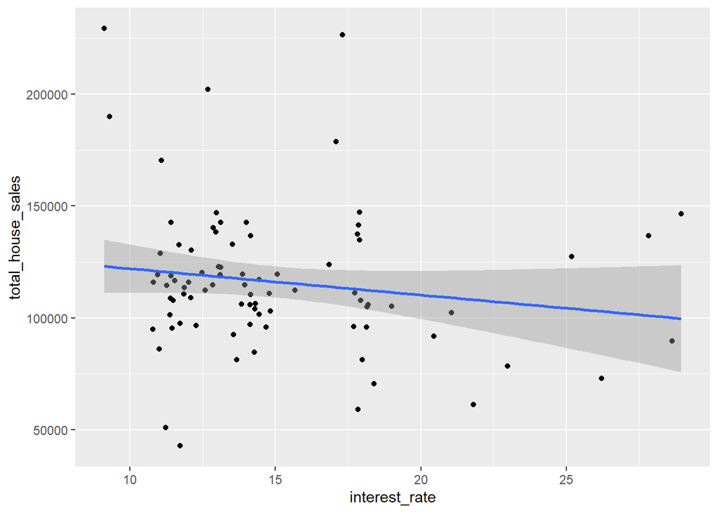

```r
ggplot(all_data_table ,aes(x=interest_rate,y=total_house_sales)) + geom_point() +geom_smooth(method='lm')
```

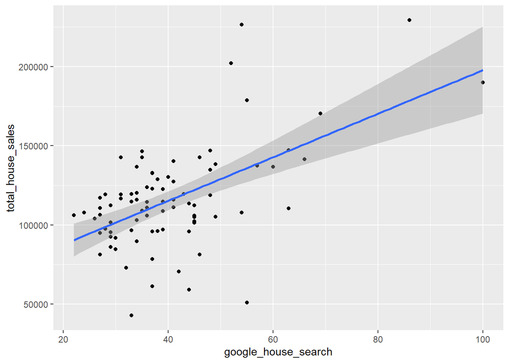

```r
ggplot(all_data_table ,aes(x= google_house_search,y=total_house_sales)) + geom_point() +geom_smooth(method='lm')
```

The functions add new columns to **`all_data_table`**: **`trnd`** assigns sequential numbers to rows, **`month`** and **`year`** extract and store the month and year from a **`Date`** column as character strings, aiding in trend and temporal analysis.

```r
all_data_table[,trnd:=1:.N]
all_data_table[,month:=as.character(month(Date,label=T))]
all_data_table[,year:=as.character(year(Date))]
```

Below you can see the correlation between the data-sets for each month.

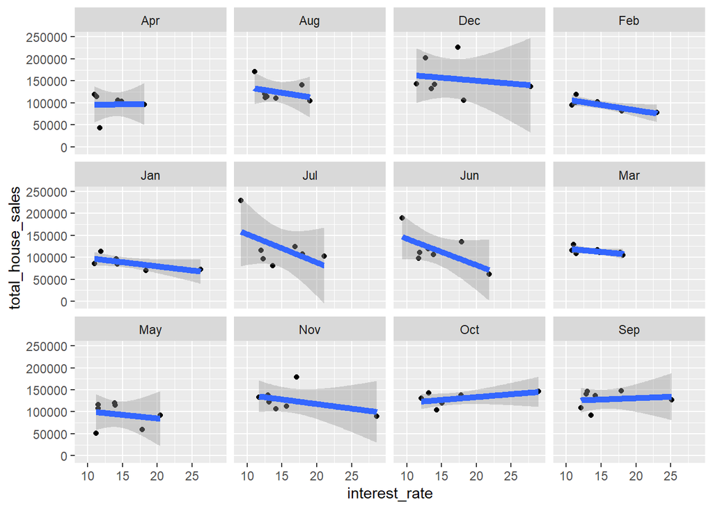

```r
ggplot(all_data_table,aes(x=interest_rate,y=total_house_sales)) +
        geom_point() + geom_smooth(method=lm,linewidth=2) + facet_wrap(~month,drop = TRUE)
```

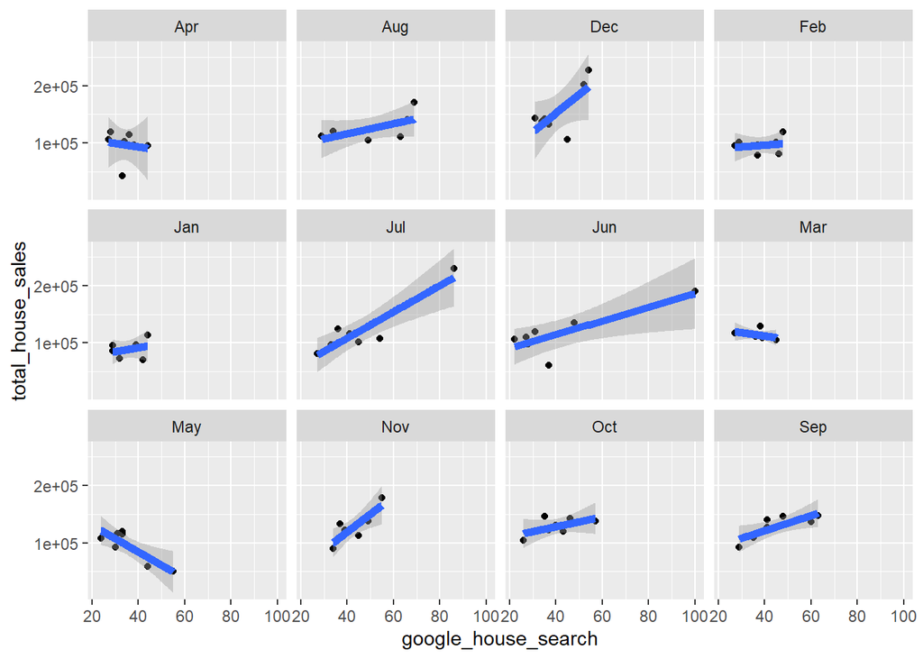

```r
ggplot(all_data_table,aes(x=google_house_search,y=total_house_sales)) +
        geom_point() + geom_smooth(method=lm,linewidth=2) + facet_wrap(~month)
```

The graph below shows the acf plot for total_house_sales the data-set. This plot shows whether the data is correlated within itself.

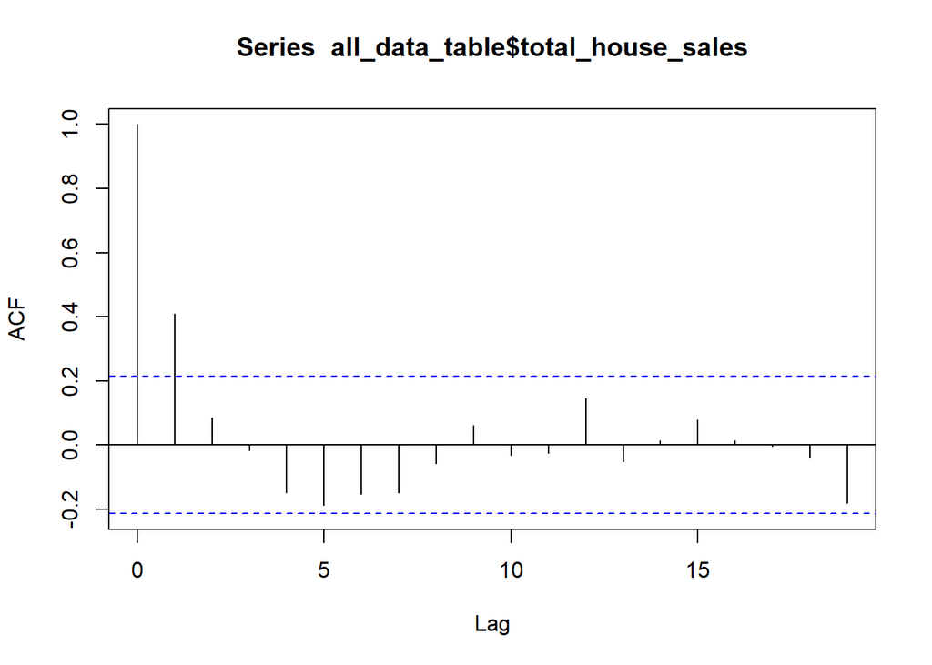

```r
acf(all_data_table$total_house_sales)
```

```r
model=lm(total_house_sales~trnd,all_data_table)
summary(model)
```

```
##
## Call:
## lm(formula = total_house_sales ~ trnd, data = all_data_table)
##
## Residuals:
##    Min     1Q Median     3Q    Max
## -79942 -14987   -551  12808 105713
##
## Coefficients:
##             Estimate Std. Error t value Pr(>|t|)
## (Intercept) 103110.6     6972.7  14.788   <2e-16 ***
## trnd           306.5      142.5   2.151   0.0345 *
## ---
## Signif. codes:  0 '***' 0.001 '**' 0.01 '*' 0.05 '.' 0.1 ' ' 1
##
## Residual standard error: 31670 on 82 degrees of freedom
## Multiple R-squared:  0.05339,    Adjusted R-squared:  0.04185
## F-statistic: 4.625 on 1 and 82 DF,  p-value: 0.03445
```

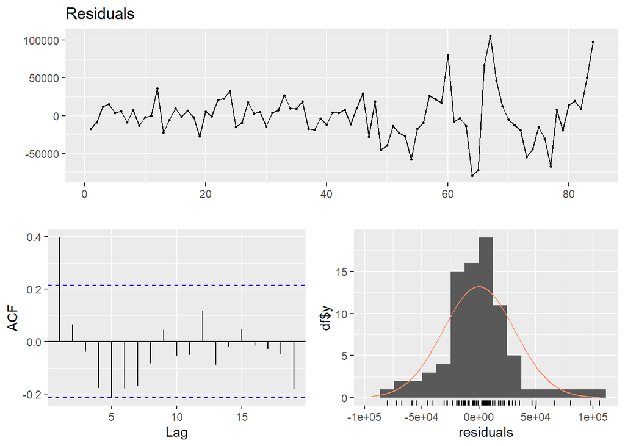

```
##
##  Ljung-Box test
##
## data:  Residuals
## Q* = 27.818, df = 10, p-value = 0.001931
##
## Model df: 0.   Total lags used: 10
```

```r
checkresiduals(model$residuals)
```

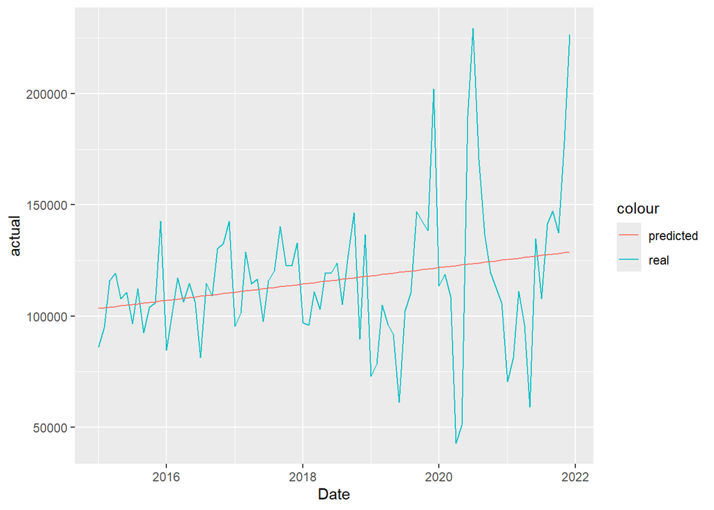

```r
tmp_data=copy(all_data_table)
tmp_data[,actual:=total_house_sales]
tmp_data[,predicted_trend:=predict(model,tmp_data)]
tmp_data[,residual_trend:=actual-predicted_trend]
ggplot(tmp_data ,aes(x=Date)) +
        geom_line(aes(y=actual,color='real')) +
        geom_line(aes(y=predicted_trend,color='predicted'))
```

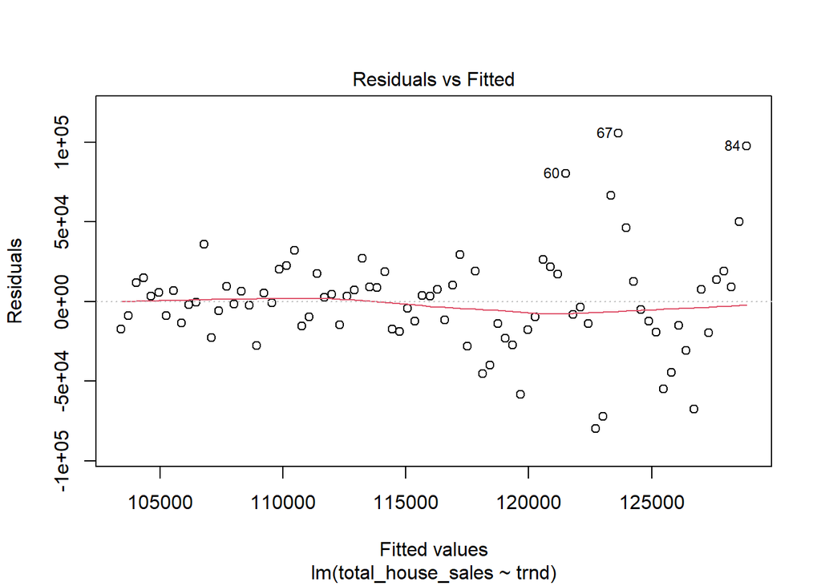

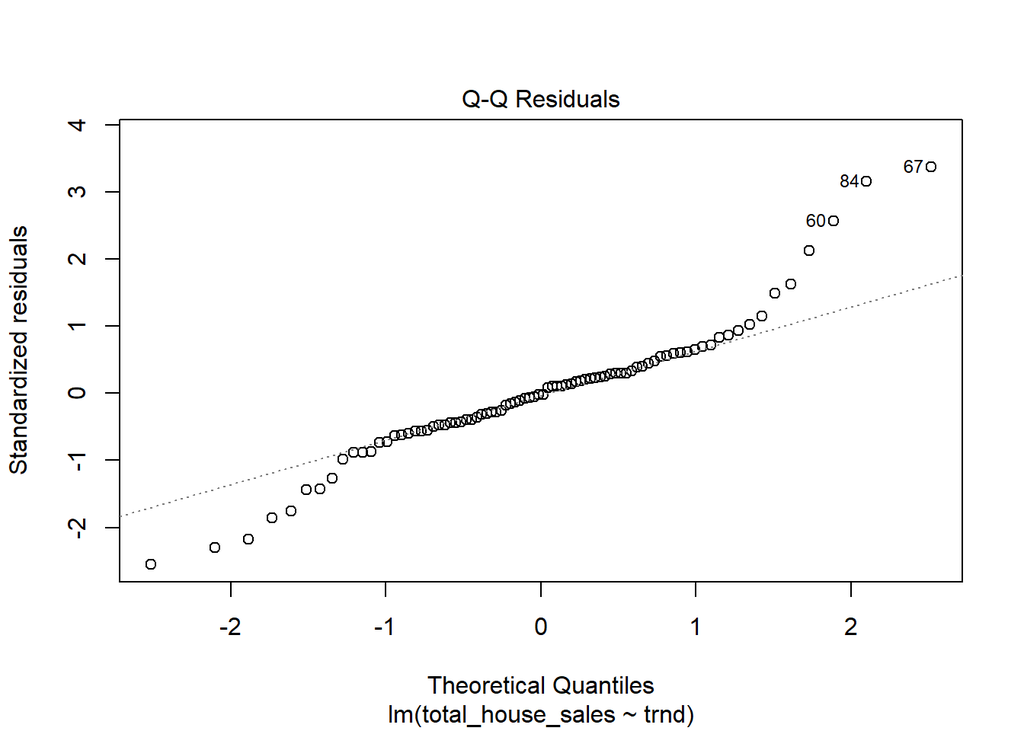

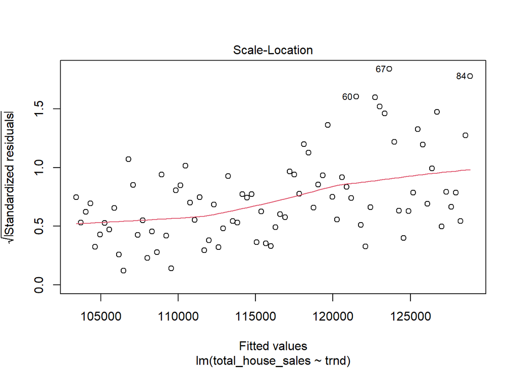

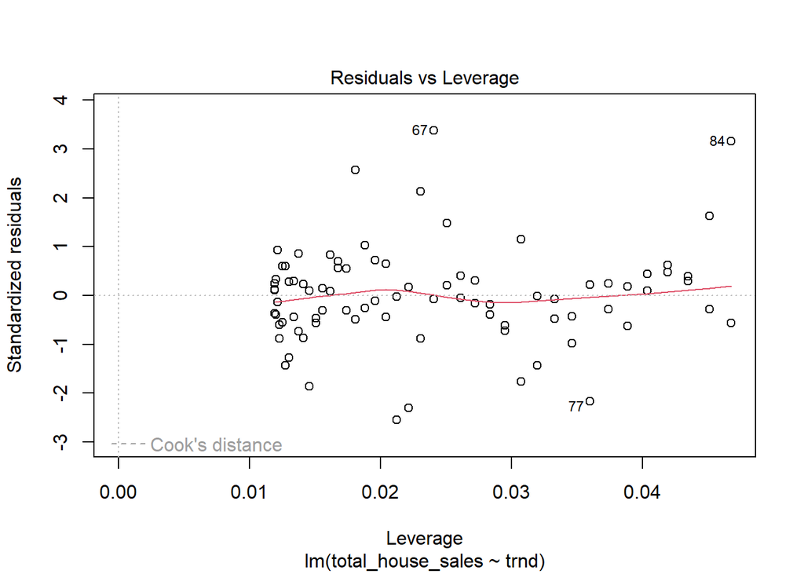

```r
plot(model)
```

For next step I added the interest rate factor to the model. In this linear regression model, total house sales are predicted by trend and interest rate, revealing a positive association with the trend (coefficient = 439.9, p-value = 0.00399) and a negative relationship with the interest rate (coefficient = -2086.5, p-value = 0.01552). The model has an improved fit compared to the previous one, with an R-squared value of 0.1198, indicating that these factors together account for approximately 12% of the variance in house sales.

```r
model=lm(total_house_sales~trnd+interest_rate,all_data_table)
summary(model)
```

```
##
## Call:
## lm(formula = total_house_sales ~ trnd + interest_rate, data = all_data_table)
##
## Residuals:
##    Min     1Q Median     3Q    Max
## -89716 -16711   -727  11410  96860
##
## Coefficients:
##               Estimate Std. Error t value Pr(>|t|)
## (Intercept)   128804.7    12401.0  10.387  < 2e-16 ***
## trnd             439.9      148.4   2.964  0.00399 **
## interest_rate  -2086.5      844.0  -2.472  0.01552 *
## ---
## Signif. codes:  0 '***' 0.001 '**' 0.01 '*' 0.05 '.' 0.1 ' ' 1
##
## Residual standard error: 30730 on 81 degrees of freedom
## Multiple R-squared:  0.1198, Adjusted R-squared:  0.09807
## F-statistic: 5.513 on 2 and 81 DF,  p-value: 0.005694
```

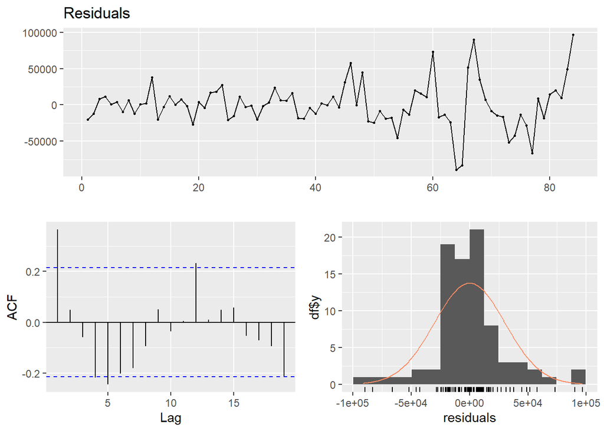

```
##
##  Ljung-Box test
##
## data:  Residuals
## Q* = 29.799, df = 10, p-value = 0.0009238
##
## Model df: 0.   Total lags used: 10
```

```r
checkresiduals(model$residuals)
```

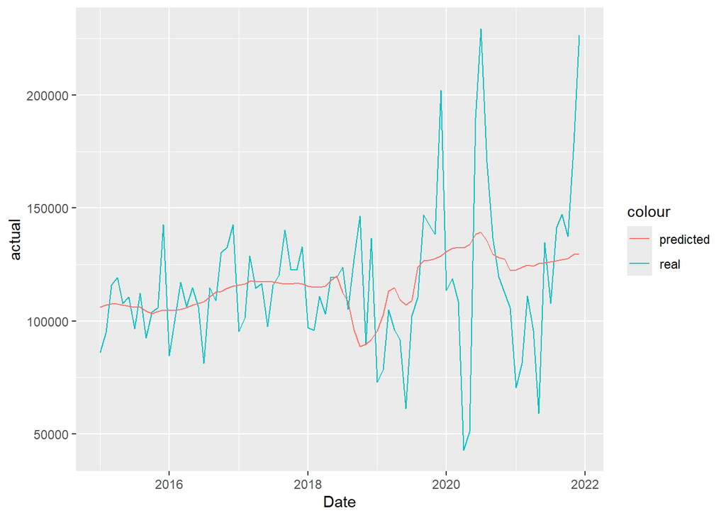

```r
tmp_data=copy(all_data_table)
tmp_data[,actual:=total_house_sales]
tmp_data[,predicted_trend_house_interest_rate:=predict(model,tmp_data)]
tmp_data[,residual_trend_house_interest_rate:=actual-predicted_trend_house_interest_rate]
#head(tmp)
ggplot(tmp_data ,aes(x=Date)) +
        geom_line(aes(y=actual,color='real')) +
        geom_line(aes(y=predicted_trend_house_interest_rate,color='predicted'))
```

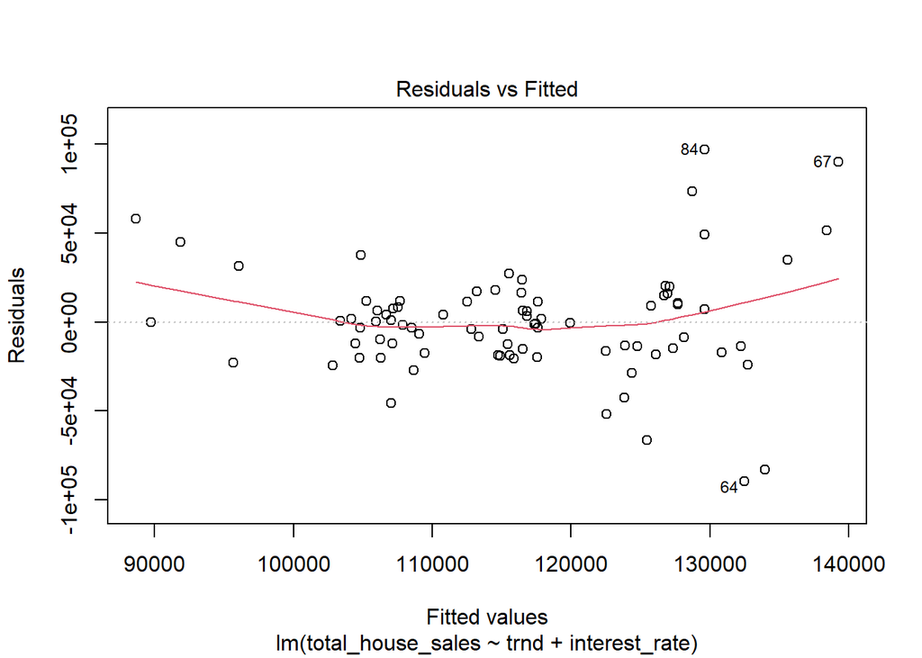

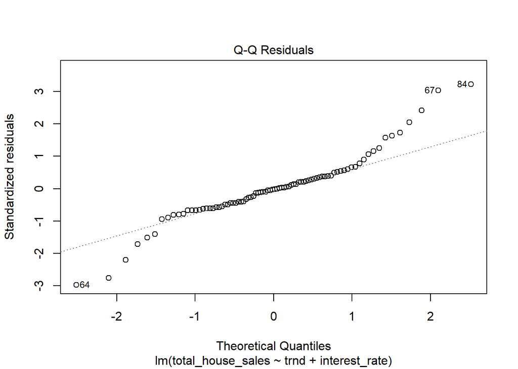

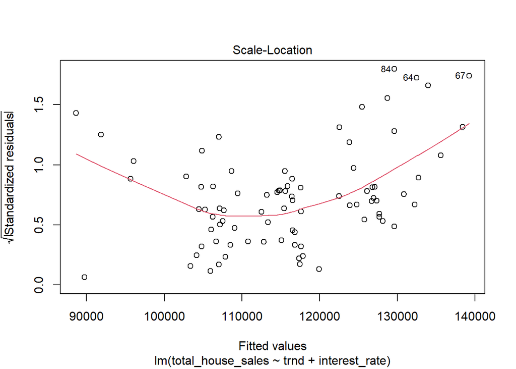

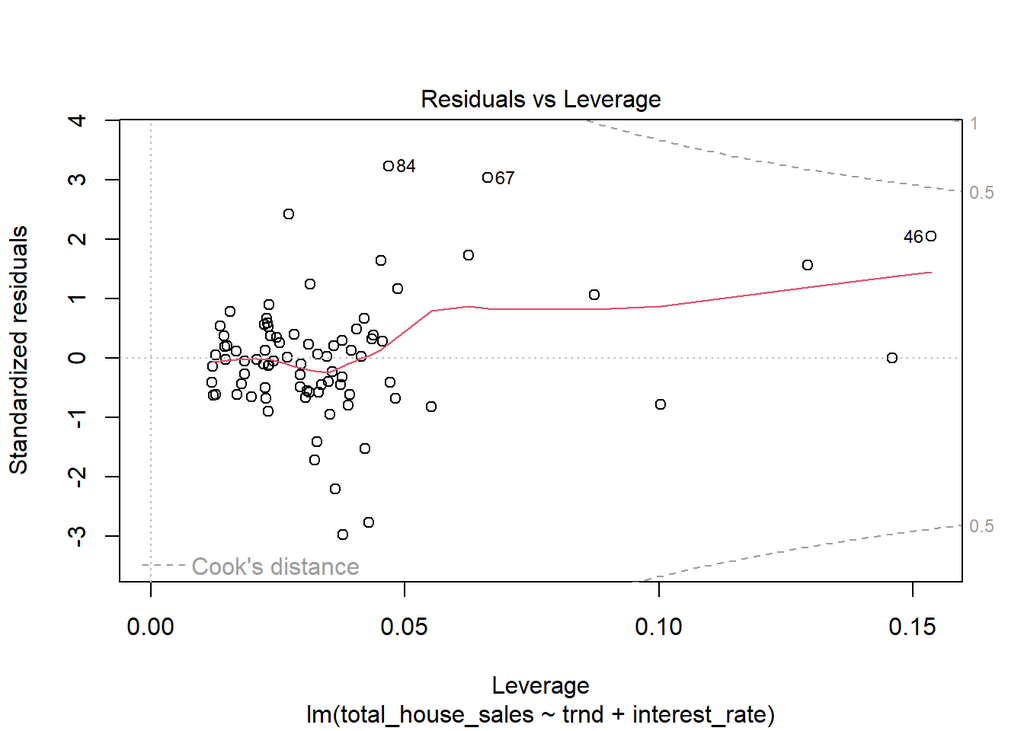

```r
plot(model)
```

For the next step I’m also adding the number of searches for houses on google to our model. In the expanded linear regression model, total house sales are influenced by trend, interest rate, and Google searches for houses. Google searches have a strong positive effect (coefficient = 1801.9, p-value < 0.0001), while trend and interest rate have less significant impacts. The model’s R-squared value of 0.35 indicates it explains 35% of the variance in total house sales, showing a considerable improvement in model fit and suggesting that Google searches are a significant predictor of house sales.

```r
model=lm(total_house_sales~trnd+interest_rate+google_house_search,all_data_table)
summary(model)
```

```
##
## Call:
## lm(formula = total_house_sales ~ trnd + interest_rate + google_house_search,
##     data = all_data_table)
##
## Residuals:
##    Min     1Q Median     3Q    Max
## -84408 -14587    303  12263 100762
##
## Coefficients:
##                     Estimate Std. Error t value Pr(>|t|)
## (Intercept)          60727.2    16691.5   3.638 0.000485 ***
## trnd                  -336.9      194.4  -1.733 0.086870 .
## interest_rate         -230.5      808.9  -0.285 0.776359
## google_house_search   1801.9      338.6   5.322 9.13e-07 ***
## ---
## Signif. codes:  0 '***' 0.001 '**' 0.01 '*' 0.05 '.' 0.1 ' ' 1
##
## Residual standard error: 26570 on 80 degrees of freedom
## Multiple R-squared:   0.35,  Adjusted R-squared:  0.3256
## F-statistic: 14.36 on 3 and 80 DF,  p-value: 1.434e-07
```

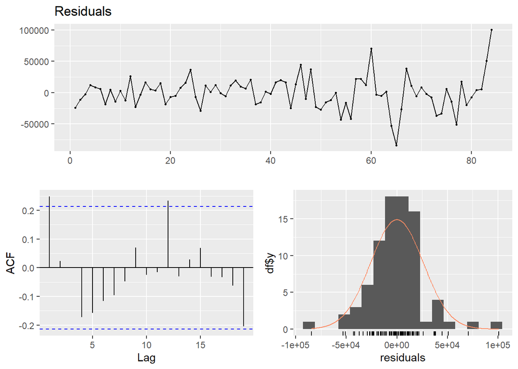

```
##
##  Ljung-Box test
##
## data:  Residuals
## Q* = 13.182, df = 10, p-value = 0.2137
##
## Model df: 0.   Total lags used: 10
```

```r
checkresiduals(model$residuals)
```

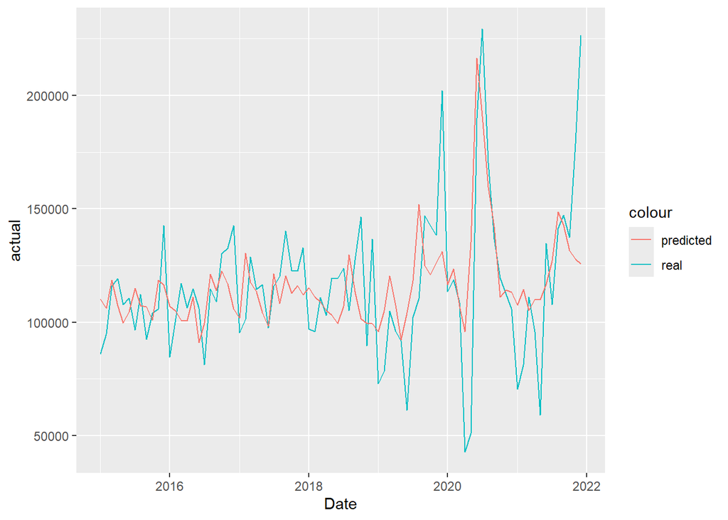

```r
tmp_data=copy(all_data_table)
tmp_data[,actual:=total_house_sales]
tmp_data[,predicted_trend_house_interest_rate_search:=predict(model,tmp_data)]
tmp_data[,residual_trend_house_interest_rate_search:=actual-predicted_trend_house_interest_rate_search]
#head(tmp)
ggplot(tmp_data ,aes(x=Date)) +
        geom_line(aes(y=actual,color='real')) +
        geom_line(aes(y=predicted_trend_house_interest_rate_search,color='predicted'))
```

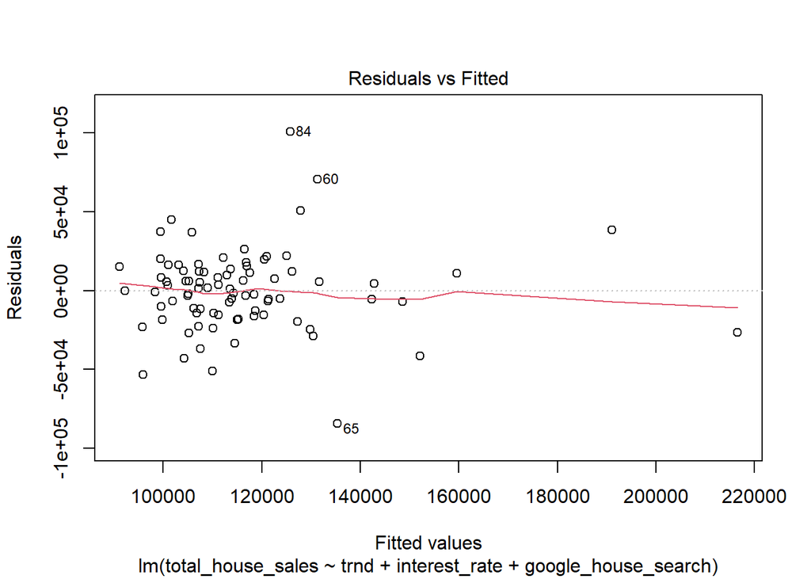

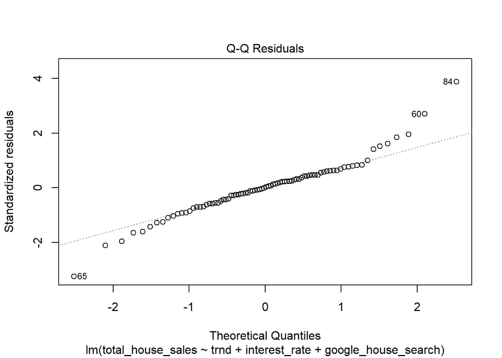

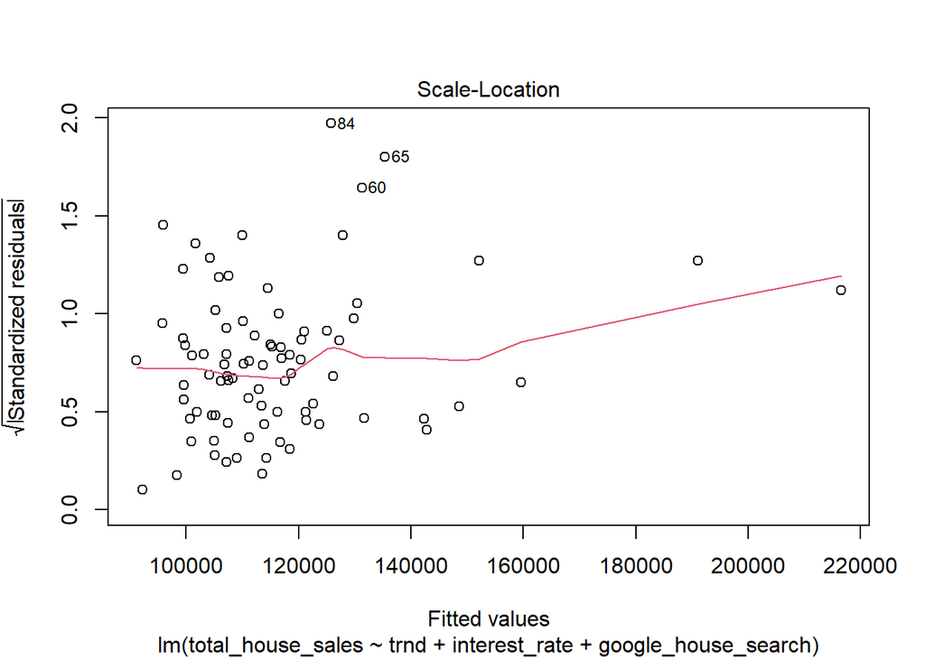

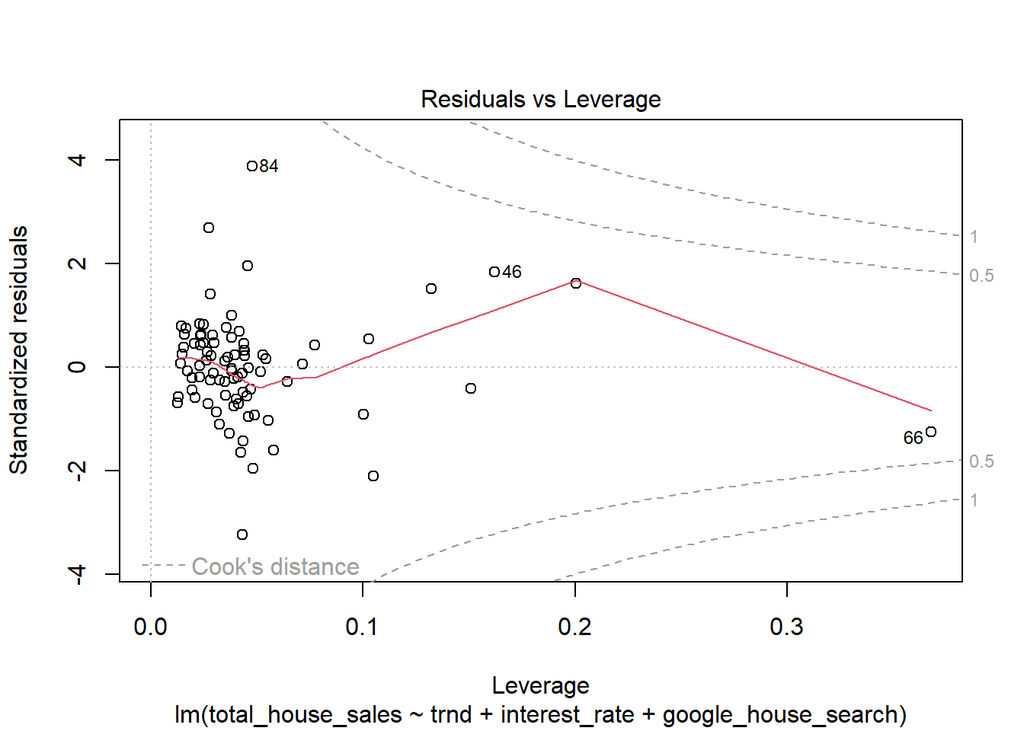

```r
plot(model)
```

```r
model=lm(total_house_sales~trnd+interest_rate+google_house_search+year,all_data_table)
summary(model)
```

```
##
## Call:
## lm(formula = total_house_sales ~ trnd + interest_rate + google_house_search +
##     year, data = all_data_table)
##
## Residuals:
##    Min     1Q Median     3Q    Max
## -69678 -10534   1344  11869  75604
##
## Coefficients:
##                      Estimate Std. Error t value Pr(>|t|)
## (Intercept)           59390.8    16409.2   3.619 0.000537 ***
## trnd                   3870.2      787.0   4.918 5.13e-06 ***
## interest_rate         -1841.2      871.3  -2.113 0.037957 *
## google_house_search    1532.0      301.8   5.076 2.78e-06 ***
## year2016             -42914.0    12972.9  -3.308 0.001453 **
## year2017             -93327.6    20505.0  -4.551 2.05e-05 ***
## year2018            -129728.2    28170.1  -4.605 1.68e-05 ***
## year2019            -191684.6    36655.6  -5.229 1.52e-06 ***
## year2020            -253913.2    45811.8  -5.543 4.36e-07 ***
## year2021            -284446.7    54321.6  -5.236 1.48e-06 ***
## ---
## Signif. codes:  0 '***' 0.001 '**' 0.01 '*' 0.05 '.' 0.1 ' ' 1
##
## Residual standard error: 22720 on 74 degrees of freedom
## Multiple R-squared:  0.5604, Adjusted R-squared:  0.5069
## F-statistic: 10.48 on 9 and 74 DF,  p-value: 2.863e-10
```

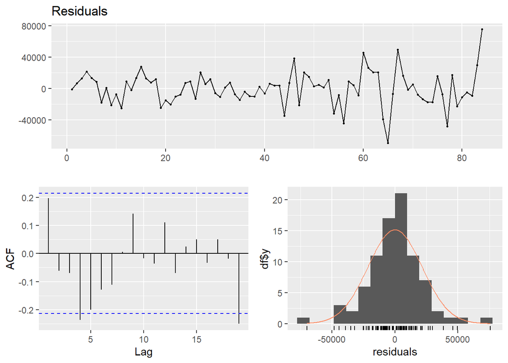

```
##
##  Ljung-Box test
##
## data:  Residuals
## Q* = 17.49, df = 10, p-value = 0.0642
##
## Model df: 0.   Total lags used: 10
```

```r
checkresiduals(model$residuals)
```

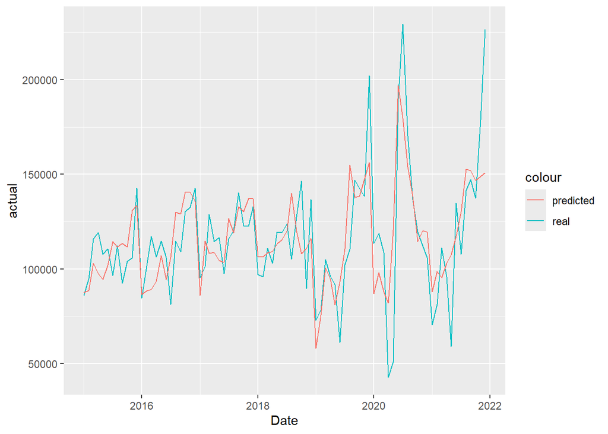

```r
tmp_data=copy(all_data_table)
tmp_data[,actual:=total_house_sales]
tmp_data[,predicted_trend_house_interest_rate_search:=predict(model,tmp_data)]
tmp_data[,residual_trend_house_interest_rate_search:=actual-predicted_trend_house_interest_rate_search]
#head(tmp)
ggplot(tmp_data ,aes(x=Date)) +
        geom_line(aes(y=actual,color='real')) +
        geom_line(aes(y=predicted_trend_house_interest_rate_search,color='predicted'))
```

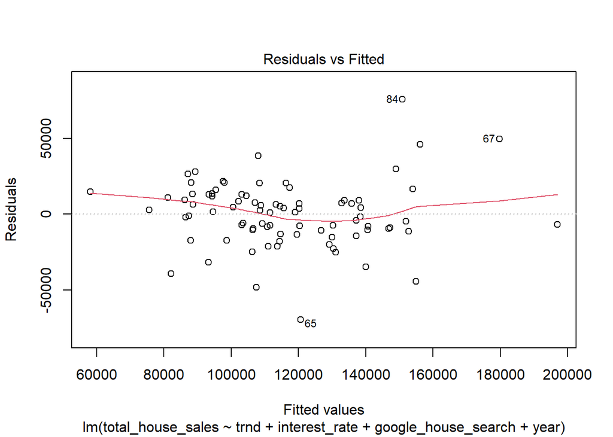

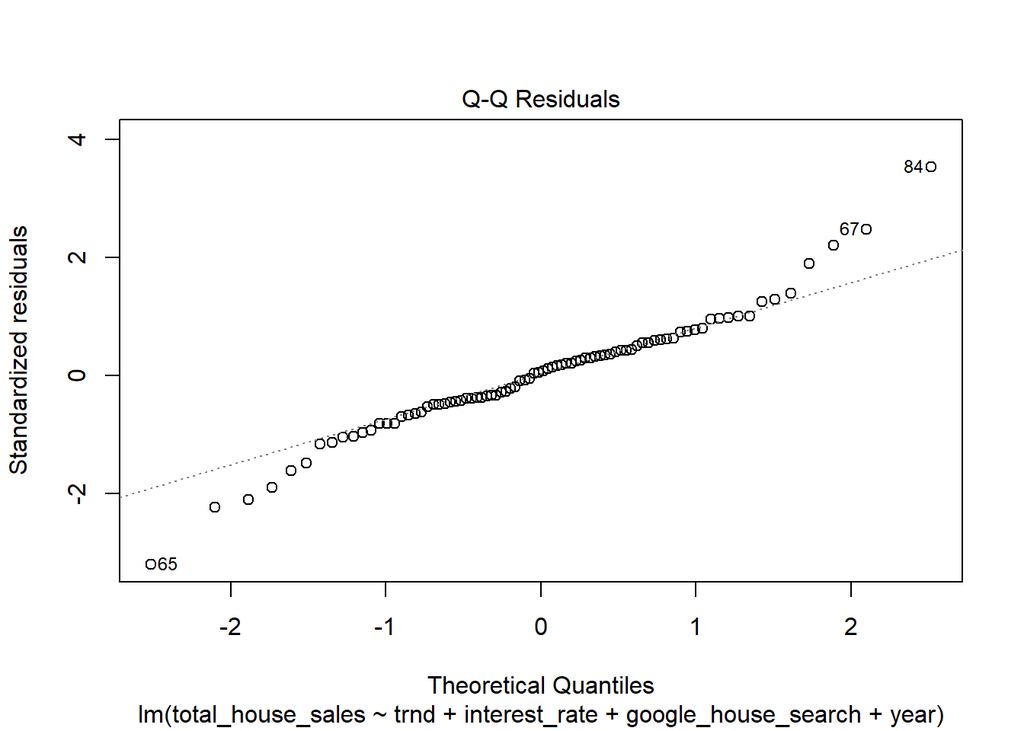

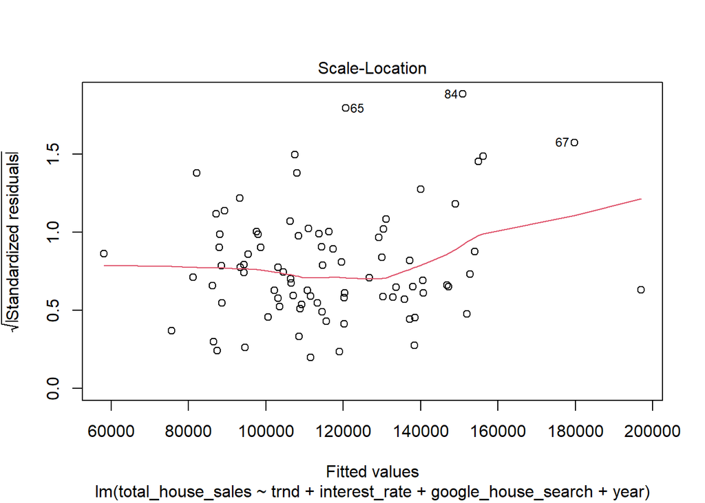

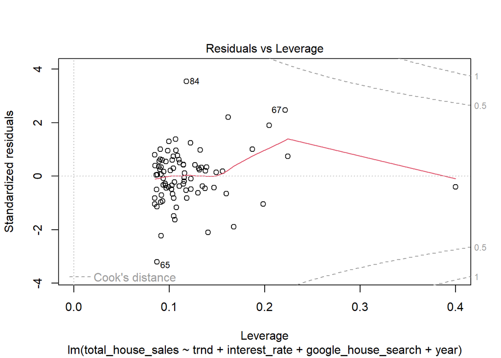

```r
plot(model)
```